# Lab 2

Not Team One

1/23/2019

## About the Team

Team Name: Not Team One

## About Rachel

[figure not shown]

Picture from Camping in Yellowstone

- Whenever I make mac and cheese, I accidentally drop the cheese packet into the boiling water when I pour the noodles in. I would like to conduct a series of mac and cheese related test among a sample of college students and then analyze the data to decide how likely it is to drop the cheese packet into the pot prematurely.
- Six months after graduation I will be working for Target as a software engineer. I hope to earn my masters while working and become a data scientist in the next five years.
- One day, I want to leave the corporate world and get a PhD so I can make mathematical models to study climate change.
- I’m hoping to become a master of R. I would also like to get better at Python if at all possible.
- My hobbies include telling dad jokes, hiking, camping, drawing, and cooking.

## About Anderson

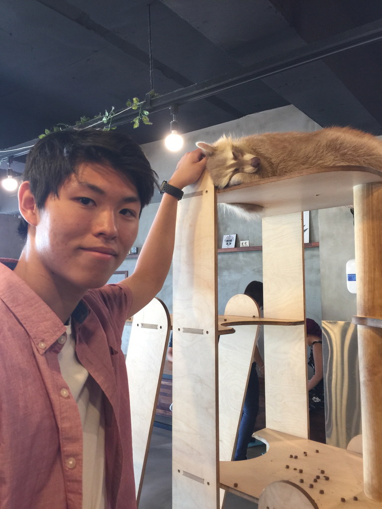

Picture with Raccoon

- During the late nate when I need a snack I sometimes get really lazy and eat ramen noodles raw. The ramen becomes a chip rather than some noodles, so I would like to know who else eats their ramen like this?
- Six months after graduation I would have a job with some coding as a part of it. Hopefully in the next five years I will be creating a space beach.
- I wish to be able to do my own research on a topic that will be me intrigued.
- I’m hoping to learn R and get a basis for coding and organizing data.
- My hobbies include longboarding, snowboarding, hiking, playing video games and listening to music.

## About David

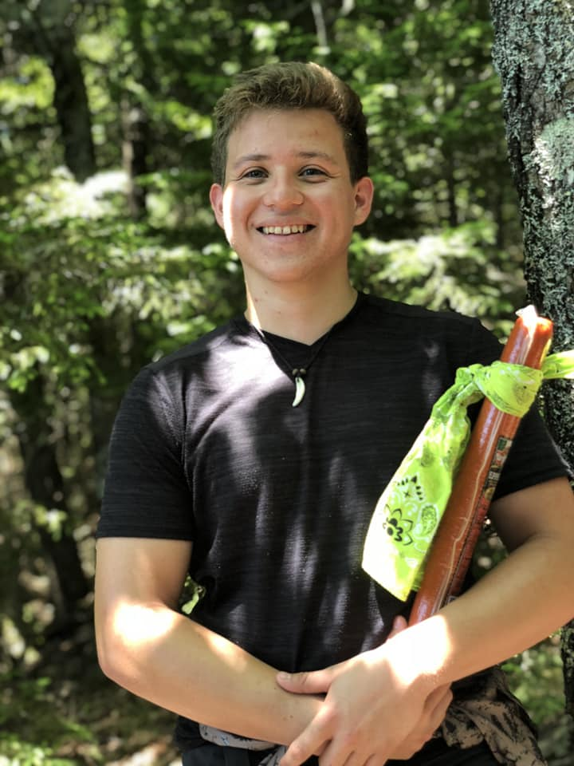

Picture from Backpacking in White Mountains